# Introduction to Supervised Learning

Intro to Data Science for Public Policy

by Jeff Chen, Georgetown University McCourt School of Public Policy

Supervised learning is used everyday whether in the social and natural sciences or web development or public policy. The term “supervised learning” comes from the nature of the empirical task, where an algorithm is *trained* to replicate labeled examples using input features and uses objective functions to minimize error or maximize information gain. Labeled examples are also known as dependent variables or target variables), and *input features* are also known as independent variables or predictors. This assumes that some combination of features can be used to describe and predict targets. For example:

1. **Public Health**. Classifying whether a restaurant is at [risk of violating city health regulations](https://www.drivendata.org/competitions/5/) using past ratings as a target and restaurant reviews as an input.
2. **Labor**. Estimating the [impact of minimum wage](http://davidcard.berkeley.edu/papers/njmin-aer.pdf) on business health by using employment as a target and changes in labor laws as inputs.
3. **Environment**. Predicting whether a storm detection signature as identified in weather radar will result in property damage by using human reported damage as the target and the physical characteristics of storm cells as inputs.
4. **Housing**. Estimating the economic impact of opening a landfill by using housing prices as a target conditioned upon housing characteristics and distance from the landfill as inputs.
5. **Health**. Estimating one’s level of physically activity using smartphone accelerometer data as inputs and user-tagged labels as targets.
6. **Operations**. Forecasting call volumes at a call center to help set appropriate staffing levels to meet citizen demand.

The structure of a supervised learning project is much like taking a course on any academic subject. Let’s take the example of a calculus class. Students are taught concepts and the application of those concepts through readings and homeworks. Each concept has a structure that is learned by examining and working through practice problems that are representative of that concept. For example, when working with derivatives, the first derivative of $f(x) = x^2$ is $f'(x) = 2x$ and its second derivative is $f''(x) = 2$. Under certain conditions, certain mathematical functions such as exponential and logarithmic functions behave differently, and the rules and patterns for handling those derivatives need to be taken into account when approaching derivative problems. Eventually, the professor will schedule and administer a midterm or final covering all the different learned concepts. In preparation, a series of practice exams are typically provided to students as a way to test their knowledge. A practice exam is most helpful when the material has already been well-studied and is taken only once, using examples that were answered incorrectly as an opportunity to provide insight into gaps in knowledge. Otherwise, repeatedly taking the same practice exam will provide a false sense of mastery as a student takes and re-takes and learns the answers as opposed to the eccentricities of the subject at hand. The real test is the actual exam, in theory indicating how well concepts were understood and re-applied.

There are parallels between taking a class and supervised learning tasks. In a classroom setting, homeworks and practice tests are used to build applied skills to accomplish specific tasks, whereas the actual exam is used to determine precisely how robust those skills are. In supervised learning, the data is often times partitioned into two or more parts, then an algorithm is *trained* on at least one partition to learn underlying patterns, then the learned rules and weights are applied to the remaining part of the *hold out* sample to *test* the accuracy of the algorithm.

In application, we can approach a supervised learning problem by how one intends to use the outputs of the algorithm and the design of the algorithmic experiment.

## Supervised Learning as a Process

Algorithms are often times mentioned in technical discussions. *Artificial neural networks* and *support vector machines* are commonly found in computer vision tasks. *Linear regression* for social science, natural science and and general use. *K-Nearest Neighbors* and *K-means* clustering are common in retail and e-commerce. But ultimately, the algorithm is only one part of a whole process. Applied supervised learning is a process that is guided by a number of core considerations, including: (1) Intended use, (2) Data, (3) Algorithm development, and (4) Experiment design.

### (1) Intended use

The intended use influences the type of algorithm. It all starts with a well-formulated data-enable question that can be answered using an empirical outcome. For example:

1. “Which of the current lawsuits in the legal department’s backlog can be won?”
2. “Which prospective patients will require advanced medical treatment in the next 90 days?”
3. “What are the greatest drivers of lawsuit generation over the last 10 years?”
4. “Which patient characteristics are most associated with stroke?”

In each of these questions, a quantitative value can be used to answer a question; however, there are nuances. The first two questions are focused on *prediction* – often times a *score* that represents the chances of a outcome. The goal is to create a sure-fire, highly accurate function that can be relied upon to make solid decisions without much manual effort, but without a strong emphasis on interpreting underlying relationships. For example, prediction projects can be used to prioritize risky buildings for inspection, screen loan applicants for financial default, and surface search results. Typically, prediction problems are required for problems of significant scale, where it becomes cost prohibitive for humans to do a task themselves. A modern example is the application of computer vision to score whether certain features are contained in images. In 2012, a [Google demonstration project](https://www.wired.com/2012/06/google-x-neural-network/) using artificial neural networks showed how a computer vision algorithm can detect whether a cat is present in hundreds of thousands photographs with a high degree of accuracy. While the algorithm is accurate, the underlying “machinery” was not designed to be easily interpretted as prediction projects. Prediction projects are more operations or action-focused, often times designed to be put into *production*, or implemented to support everyday tasks.

The latter two questions are more concerned with *estimating relationships* to understand if one or more inputs are empirically associated with a target variable. While the methodologies used for estimation can yield accurate predictions, the goalis to calibrate coefficients and weights in a model that shows how an input feature is associated or potentially impacts the target. For example, a highway traffic study may find that a 1% increase in employment is associated with a 0.5% increase in highway traffic volume. July 4th weekend may increase emergency call volume by a certain percentage. Estimation often relies on linear regression methods, which are covered later in this chapter.

In either case, it is helpful to think about supervised learning as a pointer. It is easy to flag potential cases of an observed phenomena (e.g. what, which, who, where, when), but it is hard to use supervised learning to definitively provide an answer as to “why” something happens.

### (2) The Data

Upon formulating research questions, the next priority is finding usable and actionable data. At a minimum, data need to contain:

- *A target variable, labels, or Y*. Each record should be furnished with labels of what needs to be predicted. Labels can take on any structured form such as discrete or continuous values.
- *Input features or X*. A series features that be used to relate and predict the target.

Each record needs to contain a target value $y$ and at least one input feature $x$.

In addition, the qualities of the data must be aligned with the task at hand:

- *Unit of Analysis*. A well-formulated research question has a clear unit of analysis. The data must reflect the requirements of the question. A driverless car, for example, likely requires updated telemetry data in sub-second frequencies in order to accurately and safely maneuver. Providing telemetry data every five minutes do not likely meet the requirements.
- *Data Pipeline*. If the data-enabled question will be repeatedly asked, it is worth examining the reliability of the *data pipeline* and whether new data will be available when the question is asked in the future. For example, more strategic problems like a 10-year population forecast may only be conducted every year requiring data once a year, whereas more operational problems like restaurant inspections may be done on a daily basis requiring new data in order to detect new patterns every day.

### (3) Algorithm

Algorithms are a series of rules and calculations used to convert data into insight. Supervised learning algorithms are typically comprised of a scoring or mapping function, learning function and a measure of risk, accuracy or error. Given a set of “training records”, the values of input features $x$ can be mapped to values of the target $y$ using a function $f$, the relationship of which can be expressed generically in the following form: $y_i = f(x_{1,i}, x_{2,i},..., x_{k,i})$.

To optimally map $x$ to $y$, “weights” or “parameters” are calibrated to improve the fit or predictive accuracy of the scoring function. This “learning” process to find the optimal weights given the set of data is iterative and relies on a learning function that minimizes a measure of error or risk as well as maximizing accuracy. Optimization measures include Root Mean Squared Error (RMSE), Mean Absolute Percentage Error (MAPE), F-1 Score, Area Under the Curve (AUC), True Positive Rate (TPR), among others.

In short, the idea is that when accuracy is maximized, then the weights are optimal for mapping or predicting the relationship between $x$ and $y$.

Supervised learning can be divided into *regression* and *classification* tasks, each of which is dependent on the type of target variable:

- *Regression* tasks focus on cases where the target $y$ is a continuous variable, such as housing price, population, solar energy produced, revenue, traffic, etc.
- *Classification* tasks are focused on predicting whether a given value of $y$ belongs to two or more discrete classes or categories, such as yes/no, up/down, guilty/not guilty, fire/no fire, risky/unrisky, etc.

Over the next few sessions, we will take an in-depth look at the mechanics of a number of supervised learning algorithms and how they can be used in public policy.

### (4) Experiment Design

Calibrating an algorithm is not enough. Supervised learning problems usually involve partitioning data to help with ensuring accuracy of outputs and reduce the effects of *overfitting*, a condition in which an algorithm is calibrated to noise (e.g. spurious or unmeaningful patterns) as opposed to signal. An overfitted algorithm will produce unreliable and misleading results, which in turn reduces the overall utility of a model and may have negative consequences in society. For example, an employment forecast might provide qualitatively promising results, but if it is not systematically vetted for overfitting, forecasts may over or understate economic performance, thereby misinforming major decisions.

To reduce the effects of overfitting, it is necessary to develop an experiment design for training algorithms, typically involving partitioning. The idea behind partitioning is to essentially create the same environment as in a math class: break the data into two or more parts, where one partition is used to *train* the data (analogue: “algorithm studies the data”) and the other partition is used to *test* the data (analogue: “algorithm is given a test to see if it accurately absorbed the patterns into memory”). The former partition is referred to as the *training* set and the latter is referred to as the *test* or *hold out* set. Partitioning comes in many forms, but data scientists commonly rely on two types of partition procedures:

- *Train/Validate/Test* assumes that the data are partitioned into three sets. The *train* set is used to initially calibrate the algorithm. The *validation* set is used to help tune algorithm weights and input select features to include in the function. Typically, the algorithm that is calibrated in the training stage is used to predict values in the validation set in order to check for accuracy and test sensitivities of different model specifications. Once it is determined the algorithm is as good as it can be, the trained algorithm is then used to score a set of remaining examples in the *test* set in order to assess its generalizability. These three samples may be partitioned in the following proportions: train = 70%, validate = 15%, and test = 15%. 70/15/15 for short.
- *K-Folds Cross Validation*. A train/validate/test design can be extended for more exhaustive model tuning. K-folds cross validation involves partitioning the data into $k$ partitions. Then, combine $k - 1$ partitions to train an algorithm and predict the values for the $k^{th}$ part. Then, cycle through combinations of $k-1$ partitions until each of the $k$ holdout samples have been predicted. Upon doing so, the prediction accuracy can be calculated for each of the $k$ partitions as well as for all $k$ partitions together. Partitions that yield poorer accuracy relative to other partitions help provide a clue as to when an algorithm is insufficient or requires further tuning. For exhaustive testing, $k = n - 1$ such that $n - 1$ models are trained such that each of the $n$ records in a data set are predicted once.

For data where no clear labels are available, we may rely on “unsupervised learning” – a class of tasks that used to find patterns, structure, and membership using input features alone. Unsupervised learning encompasses clustering (e.g. values may naturally fall into clusters in n-dimensional space) and dimensionality reduction. We will cover unsupervised learning in Chapter 9.

With this framework in place, for the remainder of this chapter, we will explore two supervised learning algorithms that handle continuous variables, but use very different formulations: k-Nearest Neighbors (KNN) and Linear Regression.

## Ordinary Least Squares (OLS) Regression

Every year, cities and states across the United States publish measures on the performance and effectiveness of operations and policies. Performance management practitioners typically would like to know the direction and magnitude, as illustrated by a linear trend line. Is crime up? How are medical emergency response times? Are we still on budget? Which voting blocks are drifting?

For example, the monthly number of highway toll transactions in the State of Maryland is plotted over time from 2012 to early 2016. The amount is growing with a degree of seasonality. But to concisely summarize the prevailing direction of toll transactions, we can use a trend line. That trend line is an elegant solution that shows the shape and direction of a linear relationship, taking into account all values of the vertical and horizontal axes to find a line that weaves through and divides point in a symmetric fashion.

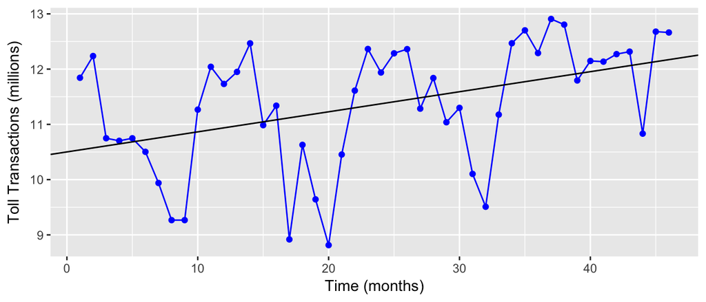

This trend line can be simply described in using the following formula:

$$\text{transactions} = 10.501 + 0.036 \times \text{months}$$

and every point plays a role. We can infer that the trend grows at approximately 36,000 transactions per month. Using the observed response $y$ and the independent variable $x$, calculating the intercept and slope is a fairly simple task:

Trend lines are one of many uses of a class of supervised learning called regression, but best known of which is Ordinary Least Squares (also referred to as Least Squares Regression or Gaussian Generalized Linear Models). There are quite a few other types of regression, such as quantile regression, non-linear least squares, partial least squares among others. In multivariate cases where many variables are used to get a handle on what factors influence $y$, the problem gets more complex.

OLS regression is the quantitative workhorse of data-driven public policy. The technique is a statistical method that estimates unknown parameters by minimizing the sum of squared differences between the observed values and predicted values of the target variable. To better understand arguably the most commonly used supervised learning method, we can start by defining a regression formula:

$$y_i = w_0 x_{i,0} + w_{1} x_{i,1} + ... + w_{k} x_{i,k} + \epsilon_{i}$$

where:

- $y_i$ is the target variable or “observed response”
- $w_{k}$ are coefficients associated with each $x_k$. Note that $w$ may be substituted with $\beta$ in some cases.
- $x_{i,k}$ are input or independent variables
- subscript $i$ indicates the index of individual observations in the data set
- $k$ is an index of position of a variable in a matrix of $x$
- $\epsilon_{i}$ is an error term that is assumed to have a normal distribution of $\mu = 0$ and constant variance $\sigma^2$

Note that $x_{i,0} = 1$, thus $w_0$ is often times represented on its own. For parsimony, this formula can be rewritten in matrix notation as follows:

$$Y = W^TX$$
such that $y$ is a vector of dimensions $n \times 1$, $x$ is a matrix with dimensions $n \times k$, and $w$ is a vector of length $k$.

Given this formula, the objective is to minimize the Sum of Squared Errors as defined as
$$SSE = \sum_{i=0}^{n}{(y_i - \hat{y})^2}$$
or the Mean Squared Error as defined as
$$MSE = \frac{1}{n}\sum_{i}^{n}{(y_i - \hat{y_i})^2}$$
. Both measures require the *predicted value* of $y$ as calculated as
$$\hat{y_i} = w_0 + w_{1} x_{i,1} + ... + w_{k} x_{i,k}$$
. The SSE and MSE are measures of uncertainty relative to the observed response. Minimization of least squares can be achieved through a method known as *gradient descent*.

#### Interpretation

There are a number of attributes of a linear squares regression model that are examined, namely the specification, coefficients, R-squared, and error.

##### Specification and coefficients

The specification is the formulation of a model, comprised of the target feature and the input features. It is often times represented loosely as:

$Y = f(x_1, x_2,...,x_n)$

Each of the $\beta$ values is a coefficient that describes the marginal relationship between each $x$ and the target $y$. Recall the toll road example.

$$\text{transactions} = 10.501 + 0.036 \times \text{months}$$

The $\beta_0$ (or y-intercept) is equal to 10.501, meaning when months = 0, the expected traffic was 10.5 million (without accounting for seasonality). The $\beta_1$ or coefficient for month is 36,000, meaning that for each additional month forward, we would expect an average 36,000 traffic increase. As we will see in the the following elaborated example, these coefficients will offer robust insights into the inner quantitative workings of the modeled relationship. As we will see in the practical example at the end of this section, there are countless ways of representing relationships.

##### R-squared

*R-squared* or $R^2$ is a measure of the proportion of variance of the target variable that can be explained by a estimated regression equation. A few key bits of information are required to calculate the $R^2$, namely:

- $\bar{y}$: the sample mean of $y$;
- $\hat{y_i}$: the predicted value of $y$ for each observation $i$ as produced by the regression equation; and
- $y_i$: the observed value of $y$ for each observation $i$.

Putting these values together is fairly simple:

- Total Sum of Squares or TSS is the variance of $y$:
  $$\text{TSS} = \sigma^2(y) = \sum_{i=1}^{n}(y_i - \hat{y})^2$$
- Sum of Squared Errors is the squared difference between each observed value of $y$ and its predicted value $\hat{y_i}$:
  $$\text{SSE} = \sum_{i=1}^{n}(y_i - \hat{y_i})^2$$
- Regression Sum of Squares or RSS is the difference between each predicted value $\hat{y_i}$ and the sample mean $\bar{y}$.

Together, $R^2 = 1 - \frac{SSE}{TSS}$. As TSS will always be the largest value, $R^2$ will always be bound between 0 and 1 where a value of $R^2 = 0$ indicates a regression line in which $x$ does not account for variation in the target whereas $R^2 = 1$ indicates a perfect regression model where $x$ accounts for all variation in $y$.

##### Error

Error can be measured in a number of ways in the OLS context. The most common is the Root Mean Square Error (RMSE), which is essentially the standard error between predictions $\hat{y_i}$ and $y_i$. RMSE is defined as $\text{RMSE} = \sigma = \sqrt{\frac{\sum_{i=1}^n(\hat{y_i}-y_i)^2}{n}}$. Note that RMSE is interpreted in terms of levels of $y$, which may not necessarily facilitate easy communication of model accuracy. For example, a $\text{RMSE = 0.05}$ in one model might appear to be small relative to a $RMSE = 164$. However, when contextualized, the former may be a larger proportion of its respective sample mean than the latter’s, indicating a less accurate fit.

There are other methods of representing error. In time series forecasts, Mean Absolute Percentage Error (MAPE) is used to contextualize prediction accuracy as a percentage of $y$. This measure is defined as $\text{MAPE} = \frac{100}{n}\sum_{i=1}^n|\frac{\hat{y_i}-y_i}{y_i}|$ and can be easily interpretted and communicated. For example, MAPE = 1.1% from one model can be compared against the MAPE = 13.5% of another model.

### In Practice

To put regression into perspective, we will predict [Maryland tollroad transactions](https://data.maryland.gov/Transportation/Toll-Transactions/hrir-ejvj) using an assortment of US county-level data. The dataset is comprised of monthly totals of tollroad transactions by county, joined with US Bureau of Labor Statistics’ [monthly employment estimates](https://www.bls.gov/cew/datatoc.htm), US Census Bureau [building permit estimates](https://www.census.gov/construction/bps/), and the Energy Information Agency’s [West Texas Crude Fuel Prices](http://www.eia.gov/dnav/pet/pet_pri_spt_s1_d.htm).

To get started, first we need to import the `tollroad_ols.csv` data file from the Lecture 6 `dataset` folder.

```r
  setwd("<set-working-directory>")
  df <- read.csv("tollroad_ols.csv")
```

##### Explore data

The dataset is provided in long form, where data from multiple geographic areas are stacked. The dataset contains eight fields:

- `date` in `YYYY-MM-DD` format.
- `year` of record.
- `fips` is the Federal Information Processing System (FIPS) code for a given county.
- `transactions` is total monthly toll transactions in a county.
- `transponders` is the total monthly toll transactions conducted using a radio frequency transponder.
- `emp` is the employment in a given month in given county.
- `bldgs` is the number of new building permits issued in a given county.
- `wti_eia` is the West Texas Intermediate spot crude price. This is the only measure that will have the same value across all geographies in a given time period.

To get a feel for the data, we use the `str()` method. All fields should be in numerical or integer form except for `date` and `fips`.

```r
  str(df[1:3,])
```

```
## 'data.frame':    3 obs. of  8 variables:
##  $ date        : Factor w/ 46 levels "2012-07-01","2012-08-01",..: 1 1 1
##  $ year        : int  2012 2012 2012
##  $ fips        : int  24003 24017 24510
##  $ transactions: int  1309632 312519 2868274
##  $ transponders: int  758737 142914 1951551
##  $ emp         : int  241401 40184 329251
##  $ bldgs       : int  84 67 8
##  $ wti_eia     : num  87.9 87.9 87.9
```

Reformatting is simple. `date` can be converted into a date object using `as.Date()` and `fips` can be converted into a factor.

```r
  df$date <- as.Date(df$date, "%Y-%m-%d")
  df$fips <- factor(df$fips)
```

Upon doing so, we can run some cursory exploratory checks ahead of formulating any models. First is to produce correlation matrix. We will beautify the text outputs using a library called `sjPlot` that formats quantitative outputs in an easier to read fashion.

The correlation matrix on the pooled data indicates finds that employment is positively associated with both transactions and transponder transactions.

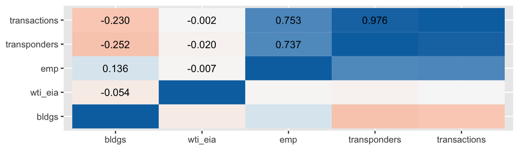

```r
  library(sjPlot)
  tab <- cor(df[,c(4:8)], use = "complete")
  sjp.corr(tab)
```

For ease of interpretation, we will use a `log-log` specification, meaning that continuous variables that enter the regression specification are transformed using a natural log. This changes the interpretation of coefficients and in may improve model fit in certain situations.

```r
  tab <- cor(log(df[,c(4:8)]), use = "complete")
  sjp.corr(tab)
```

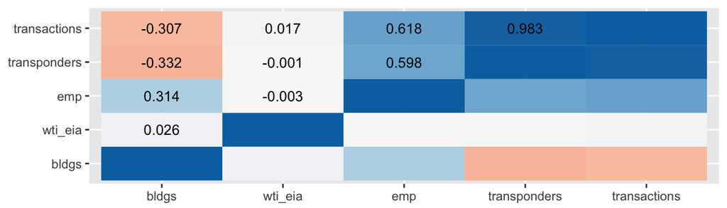

In addition, we can run an ANOVA (Analysis Of Variance) to understand if using FIPS county codes help explain the variation in transactions by looking at if the mean of transactions for each county are the same. The null hypothesis that county means are equivalent is rejected as the p-value of the F-test below is asymptotically small (< 0.01).

```r
  fit <- aov(transactions ~ fips, data = df)
  summary(fit)
```

```
##              Df    Sum Sq   Mean Sq F value Pr(>F)
## fips          5 3.381e+14 6.762e+13   526.8 <2e-16 ***
## Residuals   268 3.440e+13 1.284e+11
## ---
## Signif. codes:  0 '***' 0.001 '**' 0.01 '*' 0.05 '.' 0.1 ' ' 1
```

The same test using $log(transactions)$ yields a better fit when comparing, indicating that we may want to consider to use log-transformed target feature.

```r
  fit <- aov(log(transactions) ~ fips, data = df)
  summary(fit)
```

```
##              Df Sum Sq Mean Sq F value Pr(>F)
## fips          5 184.84   36.97   768.9 <2e-16 ***
## Residuals   268  12.88    0.05
## ---
## Signif. codes:  0 '***' 0.001 '**' 0.01 '*' 0.05 '.' 0.1 ' ' 1
```

Graphically, it is also important to develop a visual understand of how the data are distributed. Using `ggplot2`, we plot the toll transactions over time, finding a degree of seasonality and clear differences in the levels at which traffic flows through each county.

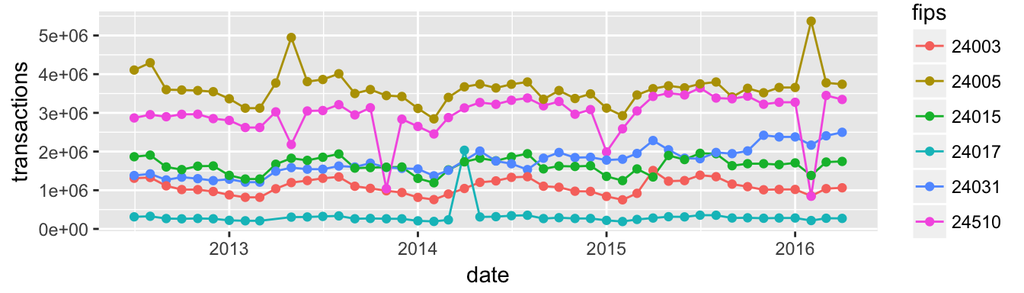

```r
  library(ggplot2)
  ggplot(data = df,
         aes(x = date, y = transactions, group = fips, colour = fips)) +
    geom_line() +  geom_point()
```

Recognizing that each county experiences different levels of traffic and economic activity, it is prudent to break apart the data into histograms for each county to expose skewedness and determine if the fundamental Gaussian assumptions of OLS are met. The histograms below indicate that there most measures can be characterized by a central tendency, but there are some measures in some counties that are significantly right skewed.

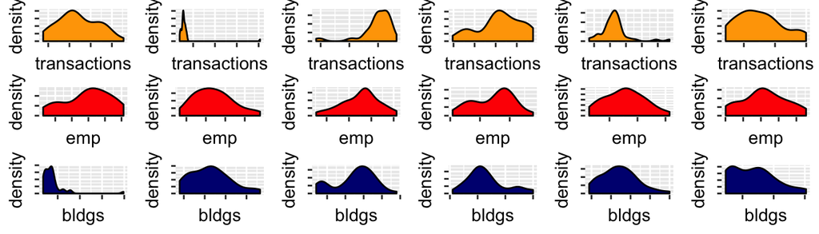

```r
  fips <- unique(df$fips)
  for(k in 1:length(fips)){
    temp <- ggplot(data = df[df$fips==fips[k],], aes(transactions)) +
            geom_density(fill = "orange") +
            theme(plot.title = element_text(size = 9), axis.text.x=element_blank(),
            axis.text.y=element_blank())
    assign(paste0("trans",k), temp)

    temp <- ggplot(data = df[df$fips==fips[k],], aes(emp)) +
            geom_density(fill = "red") +
            theme(plot.title = element_text(size = 9), axis.text.x=element_blank(),
            axis.text.y=element_blank())
    assign(paste0("emp",k), temp)

    temp <- ggplot(data = df[df$fips==fips[k],], aes(bldgs)) +
            geom_density(fill = "navy") +
            theme(plot.title = element_text(size = 9), axis.text.x=element_blank(),
            axis.text.y=element_blank())
    assign(paste0("bldgs",k), temp)

  }

  library(gridExtra)
  grid.arrange(trans1, trans2, trans3, trans4, trans5, trans6,
               emp1, emp2, emp3, emp4, emp5, emp6,
               bldgs1, bldgs2, bldgs3, bldgs4, bldgs5, bldgs6, ncol = 6)
```

This skewness can be improved by applying mathematical transformations such as $log_{10}$ or natural logarithm.

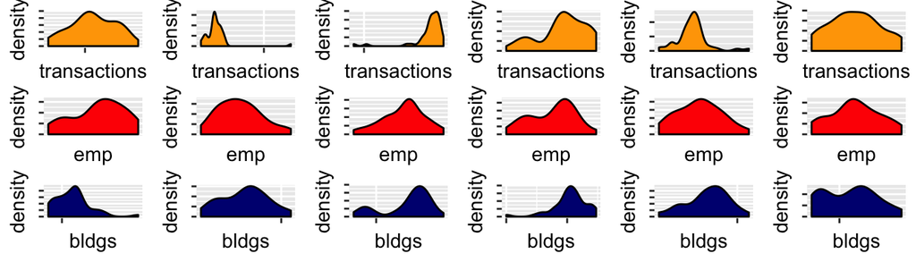

##### Set train/test samples

With a basic understanding of the patterns in the underlying data, we can partition the data for training and testing. Given the small sample of points, we will partition the data into a 60-30 split, which is approximately 2012 through 2014 and 2015 through 2016, respectively. This partition is captured in a new variable `flag`.

```r
  df$flag <- 0
  df$flag[df$year >= 2015] <- 1
```

##### Regression

Running a linear regression is a fairly simple task when using the `lm()` method. The basic syntax involves specifying the $y$, $x$ and the dataframe or matrix.

```r
  lm(<yvar> ~ <xvars> , data = <data>)
```

When evoked, the `lm()` method produces an class object that contains all the outputs of a regression model, including coefficients, fitness tests, residuals, predictions among other things.As a simple example, we will fit the specification: $\log\text{(transactions)} = \beta_0 + \beta_1 \text{log(employment)} + \epsilon$ using only the training set (`flag == 0`). We can assign the output to `fit`. To see all attributes of the `fit` object, use the `str()` method. For a high-level summary, use the `summary()` method.

The bivariate regression yielded statistically significant results for employment, indicating that a 100% increase in employment is associated with a 43% increase in highway toll transactions. The amount of variance explained is modest with an $R^2 = 0.321$ with a relatively large $RMSE = 0.6904$.

```r
  fit <- lm(log(transactions) ~ log(emp), data = df[df$flag == 0,])
  summary(fit)
```

```
##
## Call:
## lm(formula = log(transactions) ~ log(emp), data = df[df$flag ==
##     0, ])
##
## Residuals:
##     Min      1Q  Median      3Q     Max
## -1.3887 -0.5482  0.1730  0.5631  1.0330
##
## Coefficients:
##             Estimate Std. Error t value Pr(>|t|)
## (Intercept)  8.92253    0.57238  15.588   <2e-16 ***
## log(emp)     0.43759    0.04755   9.202   <2e-16 ***
## ---
## Signif. codes:  0 '***' 0.001 '**' 0.01 '*' 0.05 '.' 0.1 ' ' 1
##
## Residual standard error: 0.6904 on 176 degrees of freedom
## Multiple R-squared:  0.3248, Adjusted R-squared:  0.321
## F-statistic: 84.68 on 1 and 176 DF,  p-value: < 2.2e-16
```

The `fit` object contains other rich information about attributes of a regression model, such as the coefficients, residuals, among other features. The full detail coefficients, for instance, can be easily viewed by using the following command:

```r
  summary(fit)$coef
```

```
##              Estimate Std. Error  t value     Pr(>|t|)
## (Intercept) 8.9225327 0.57238137 15.58844 5.564812e-35
## log(emp)    0.4375895 0.04755384  9.20198 1.013823e-16
```

To view the full list of attributes contained in the regression object, use the structure method `str()`.

A common step in assessing model fitness regressions is to check if the normality assumptions are met as this will influence reliability and accuracy of the model. The residuals, for example, should be normally distributed; however, the kernel density graph below shows that the residuals (in blue) are bimodally distributed, which is not normally distributed as compared with the simulated normal distribution (yellow). This indicates provides an indication that the regression needs to be refined in order to account for other parameters.

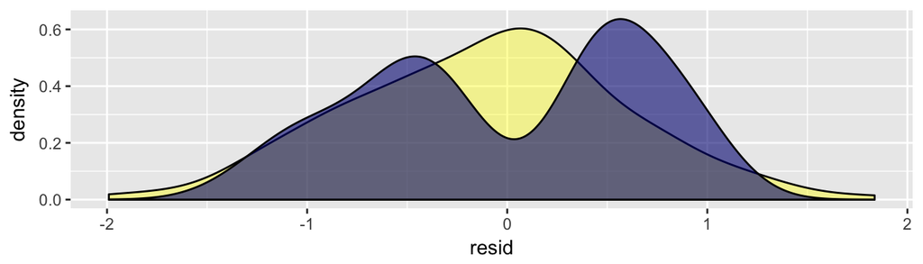

```r
  x <- data.frame(resid = fit$residuals)
  set.seed(50)
  x$norm <- rnorm(nrow(x), mean(x$resid), sd(x$resid))
  ggplot(x, aes(resid)) +
    geom_density(aes(norm), alpha = 0.4, fill = "yellow") +
    geom_density(fill = "navy", alpha = 0.6)
```

Thinking back to the earlier results of the ANOVA test, it makes sense to incorporate the `fips` feature and try a few other features. The results are far more promising, with an R-squared above 0.9 and a RMSE that is roughly one-third the size. The employment feature is statistically significant with a p-value under 0.05 with a coefficient that indicates that essentially every one-person (or 100%) increase in employment is associated with a two fold increase in trips – this makes sense as people may be commuting for work. Additional building permits (`log(bldgs)`) appear to have a modest effect as may be expected as their effect is likely lagged. The `FIPS` counties, while not fully significant, seem to help explain much of the variability.

```r
  fit <- lm(log(transactions) ~ log(emp) + log(bldgs) + log(wti_eia) + fips,
              data = df[df$flag == 0,])
  summary(fit)
```

```
##
## Call:
## lm(formula = log(transactions) ~ log(emp) + log(bldgs) + log(wti_eia) +
##     fips, data = df[df$flag == 0, ])
##
## Residuals:
##      Min       1Q   Median       3Q      Max
## -1.02680 -0.07561 -0.00165  0.08227  1.89656
##
## Coefficients:
##               Estimate Std. Error t value Pr(>|t|)
## (Intercept)  -19.44813   12.19007  -1.595  0.11249
## log(emp)       2.57132    0.96714   2.659  0.00860 **
## log(bldgs)     0.08442    0.04349   1.941  0.05391 .
## log(wti_eia)   0.20735    0.14657   1.415  0.15900
## fips24005      0.34271    0.36643   0.935  0.35098
## fips24015      6.04985    2.03225   2.977  0.00334 **
## fips24017      3.44118    1.75090   1.965  0.05101 .
## fips24031     -1.14389    0.57376  -1.994  0.04780 *
## fips24510      0.45659    0.30409   1.502  0.13509
## ---
## Signif. codes:  0 '***' 0.001 '**' 0.01 '*' 0.05 '.' 0.1 ' ' 1
##
## Residual standard error: 0.2103 on 169 degrees of freedom
## Multiple R-squared:  0.9398, Adjusted R-squared:  0.937
## F-statistic:   330 on 8 and 169 DF,  p-value: < 2.2e-16
```

A cursory look at the residuals finds a much more normally distributed set of residuals, indicating that incorporating the `FIPS` codes enables better a more proper model.

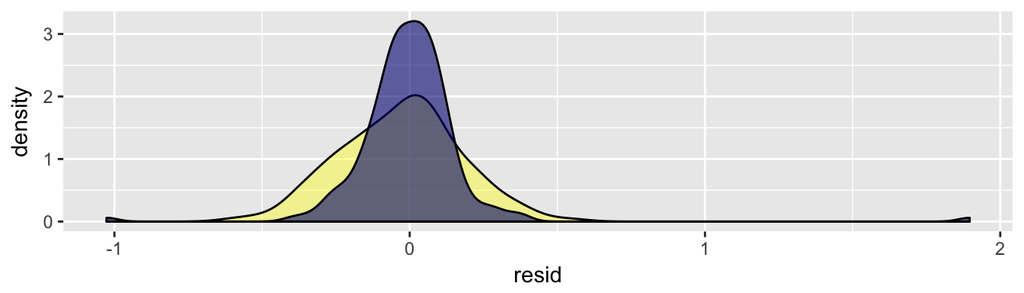

```r
  x <- data.frame(resid = fit$residuals)
  set.seed(50)
  x$norm <- rnorm(nrow(x), mean(x$resid), sd(x$resid))
  ggplot(x, aes(resid)) +
    geom_density(aes(norm), alpha = 0.4, fill = "yellow") +
    geom_density(fill = "navy", alpha = 0.6)
```

##### Prediction

The critical step is the prediction step, using the trained regression model to score the test set. In this example, both train and test sets are contained in data frame `df`. Generating predicted values $\hat{y}$ using the input features is a simple task that relies on the `predict()` method. The method accepts the regression object and a new dataset. In our example, we input use `fit` and `df`. The output is a vector of predictions for each line of `df`. We assign this vector as a new column as `df`.

```r
  df$yhat <- predict(fit, newdata = df)
```

With the prediction available, a Mean Absolute Percentage Error (MAPE) can be used to quantify the model fit in terms that are interpretable. To do so, we first need to write a MAPE function.

```r
  mape <- function(y_hat, y){
    return(mean(abs(y_hat/y-1), na.rm=T))
  }
```

Upon doing so, we can compare the performance of the model in the training phase and the test phase. The error rate of the training set was 0.8% and grows to 1.4% in the test set, indicating some degree of overfitting. However, in absolute terms, the errors are relatively small.

```r
  #train error
    train_error <- mape(df[df$flag == 0, "yhat"], log(df[df$flag == 0, "transactions"]))
    print(paste0("MAPE-train = ", train_error))
```

```
## [1] "MAPE-train = 0.00804538836113271"
```

```r
  #test error
    test_error <- mape(df[df$flag == 1, "yhat"], log(df[df$flag == 1, "transactions"]))
    print(paste0("MAPE-test = ", test_error))
```

```
## [1] "MAPE-test = 0.0143640376481522"
```

The predictions can be compared against the actual transactional volumes using an ordinary scatter plot. To contextualize the predictions, we also add a 45-degree line that indicates how accurate predictions are relative to actual. Deviations below the line suggest that predictions are underestimation and above the line indicates overestimation. The effects of overfitting are clear in the models when comparing training results to test results. The training sample (left graph) predictions are spot on with predictions landing on the diagonal, whereas some of the test sample (right graph) stray below the line.

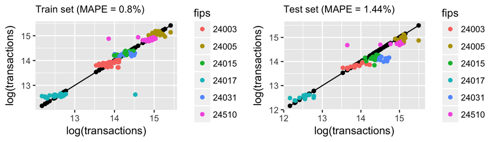

```r
  library(gridExtra)

  g1 <-  ggplot(data = df[df$flag == 0, ],
                aes(x = log(transactions), y = log(transactions))) +
          geom_line() +  geom_point()  +
          ggtitle(paste0("Train set (MAPE = ",round(100*train_error,2),"%)")) +
          geom_point(aes(x = log(transactions), y = yhat, colour = fips)) +
          theme(plot.title = element_text(size = 10), )

  g2 <-  ggplot(data = df[df$flag == 1, ],
                aes(x = log(transactions), y = log(transactions))) +
          geom_line() +  geom_point()  +
          ggtitle(paste0("Test set (MAPE = ",round(100*test_error,2),"%)")) +
          geom_point(aes(x = log(transactions), y = yhat, colour = fips)) +
          theme(plot.title = element_text(size = 10))

  grid.arrange(g1, g2, ncol=2)
```

#### Exercises 6.1

1. Run a regression for `FIPS = 24015` where $Y$ is $log(transactions)$ and $X$ are log(emp), log(bldgs), and log(wti_eia).
2. Obtain the training and testing MAPEs for `FIPS = 24015`. How does this compare to the MAPE for `FIPS = 24015` from the example pooled model?

## k-Nearest Neighbors (kNN)

K-nearest neighbors (KNN) is a non-parametric pattern recognition algorithm that is based on a simple idea: observations that are more similar will likely also be located in the same neighborhood. Given a class label $y$ associated with input features $x$, a given record $i$ in a dataset can be related to all other records using Euclidean distances in terms of $x$:

$$\text{distance} = \sqrt{\sum(x_{ij} - x_{0j})^{2} }$$

How does one implement this exactly? To show this process, pseudocode will be relied upon. It’s an informal language to articulate and plan the steps of an algorithm or program, principally using words and text as opposed to formulae. There are different styles of pseudocode, but the general rules are simple: indentation is used to denote a dependency (e.g. control structures). For all techniques, we will provide pseudocode, starting with kNN:

##### Pseudocode

```
kNN( k, set, y, x){
  Pre-Process (optional):
    > Transform or standardize all input features

  Loop through each `item` in `set`{
    > Calculate vector of distances in terms of x from `item` to all other items in `set`
    > Rank distance in ascending order

    if target `y` is continuous:
      > Calculate mean of `y` for items ranked 1 through k
    else if target is discrete:
      > Calculate share of each discrete level for items ranked 1 through k
      > Use majority voting to derive expected value
  }
}
```

The procedure described above yields the results for just one value of $k$. However, kNNs, like many other algorithms, are an iterative procedure, requiring tuning of *hyperparameters* – or values that are starting and guiding assumptions of a model. In the case of kNNs, $k$ is a hyperparameter and we do not precisely know the best value of $k$. Often times, tuning of hyperparameters involves a *grid search*, a process whereby a range of possible hyperparameters is determined and the algorithm is tested at equal intervals from the minimum to maximum of that tuning range.

To illustrate this, a two-dimensional dataset with a target $y$ that takes of values $0$ and $1$ has been plotted below. Graph (1) plots the points, color-coded by their labels. Graph (2), (3), and (4) show the results of a grid search along intervals of a $log_{10}$ scale, where the background is color-coded as the predicted label for the corresponding value of $k$. In addition to $k$, two measures are provided above each graph to help contextualize predictions: the True Positive Rate or $TPR$ and the True Negative Rate or $TNR$.

The $TPR$ is defined as $TPR = \frac{\text{Number of values that were correctly predicted}}{\text{Number of actual cases values}}$. The $TNR$ is similarly defined as $TNR = \frac{\text{Number negative values that were correctly predicted}}{\text{Number of actual negative values}}$. Both are measures bound between 0 and 1, where higher values indicate a higher degree of accuracy. A high $TPR$ and low $TNR$ indicates that the algorithm is ineffective in distinguishing between positive and negative cases. The same is true with a low $TPR$ and high $TNR$. This is exactly the case in Graph (4) where all points are classified as $Y = 1$, which is empirically characterized by $TNR = 0.02$ and $TPR = 1$.

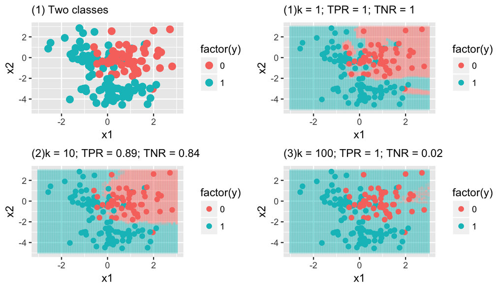

##### Which K is the right K?

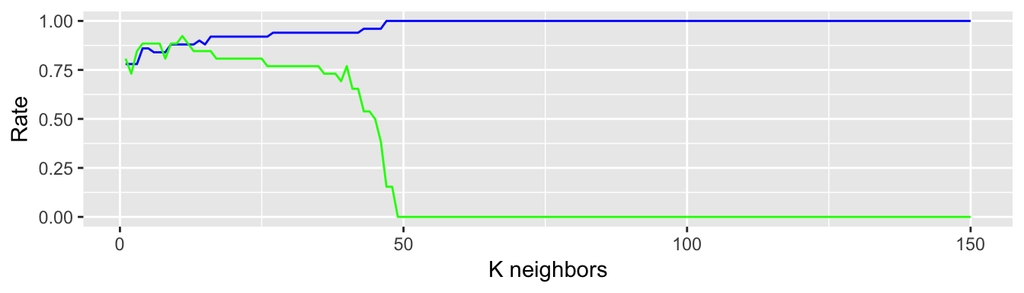

There are other factors that influence the selection of $k$:

- Scale. kNNs are strongly influenced by the scale and unit of values of $x$ as ranks are dependent on straight Euclidean distances. For example, if a dataset contained random measurements of age in years (a relatively nor) and wealth in dollars, the units will over emphasize income as the range varies from 0 to billions whereas age is on a range of 0 to 100+. To ensure equal weights, it is common to transform variables into standardized scales such as:
  - Range scaled or
    $$\frac{x - \min(x)}{\max(x)-\min(x)}$$
    yields scaled units between 0 and 1, where 1 is the maximum value
  - Mean-centered or
    $$\frac{x - \mu}{\sigma}$$
    yield units that are in terms of standard deviations
- Symmetry. It’s key to remember that neighbors around each point will not likely be uniformly distributed. While kNN does not have any probabilistic assumptions, the position and distance of neighboring points may have a skewing effect.

#### Usage

KNNs are efficient and effective under certain conditions. First, kNNs can handle target values that are either discrete or continuous, making the approach relatively flexible. They are best used when there are relatively few features as distances to neighbors need to be calculated for each and every record and need to be optimized by searching for the value of $k$ that optimizes for accuracy. In cases where data is randomly or uniformly distributed in fewer dimensions, a trained KNN is an effective solution to filling gaps in data, especially in spatial data. However, kNNs are not interpretable as it is a nonparametric approach – it does not produce results that have a causal relationship or illustrate. Furthermore, kNNs are not well-equipped to handle missing values.

#### An Example

In practice in `R`, KNNs can be trained using the `knn()` function in the `class` library. However, this function is best suited for discrete target variables. To illustrate KNN regressions, we will write a function from scratch and illustrate using remote sensed data. Remote sensing is data obtained through scanning the Earth from aircrafts or satellites. Remote sensed earth observations yield information about weather, oceans, atmospheric composition, human development among other things – all are fundamental for understanding the environment. As of Jan 2017, the National Aeronautics and Atmospheric Administration (NASA) maintains two low-earth orbiting (LEO) satellites named Terra and Aqua, each of which takes images of the Earth using the Moderate Resolution Imaging Spectroradiometer (MODIS) instrument. Among the many practical scientific applications of MODIS imagery is the ability to sense vegetation growth patterns using the Normalized Difference Vegetation Index (NDVI) – a measure ranging from -1 to +1 that indicates that amount of live green on the Earth’s surface. Imagery data is a $n \times m$ gridded matrix where each cell represents the NDVI value for a given latitude-longitude pair.

NASA’s Goddard Space Flight Center (GSFC) publishes monthly [MODIS NDVI composites](https://neo.sci.gsfc.nasa.gov/view.php?datasetId=MOD13A2_M_NDVI). For ease of use, the data has been reprocessed such that data are represented as three columns: latitude, longitude, and NDVI. In this example, we randomly select a proportion of the data (~30%), then use KNNs to interpolate the remaining 70% to see how close we can get to replicating the original dataset. In application, scientific data that is collected *in situ* on the Earth’s surface may take on a similar format – represembling randomly selected points that can be used to generalize the measures on a grid, even where measures were not taken. This process of interpolation and gridding of point data is the basis for inferring natural and manmind phenomena beyond where data was sampled, whether relating to the atmosphee, environment, infrastructure, among other domains.

To start, we’ll set a working directory.

```r
  setwd("[your-dir]")
```

Then read in the data, which is available in CSV form on the course [repo](https://github.com/GeorgetownMcCourt/data-science/tree/master/lecture-05/dataset).

```r
#Read CSV of data
  df <- read.csv("ndvi_sample_201606.csv")
```

To view the data, we can use the `geom_raster()` option in the `ggplot2` library. Notice the color gradations between arrid and lush areas of vegetation.

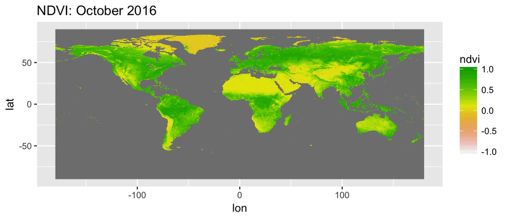

```r
  library(ggplot2)
  ggplot(df, aes(x=lon, y=lat)) +
              geom_raster(aes(fill = ndvi)) +
              ggtitle("NDVI: October 2016") +
              scale_fill_gradientn(limits = c(-1,1), colours = rev(terrain.colors(10)))
```

The NDVI data does not provide values on water. As can be seen below, cells that do not contain data are represented as 99999 and are otherwise values between -1 and +1.

```
##       lat      lon         ndvi
## 1  89.875 -179.875 9.999900e+04
## 2  89.625 -179.875 9.999900e+04
## 3  89.375 -179.875 9.999900e+04
## 74 71.625 -179.875 1.047244e-01
## 75 71.375 -179.875 4.472441e-01
## 76 71.125 -179.875 3.763779e-01
```

For this example, we will focus on an area in the Western US and extract only a 30% sample.

```r
  #Subset image to Western US near the Rocky Mountains
    us_west <- df[df$lat < 45 & df$lat > 35 &  df$lon > -119 & df$lon < -107,]

  #Randomly selection a 30% sample
    set.seed(32)
    sampled <- us_west[runif(nrow(us_west)) < 0.3 & us_west$ndvi != 99999,]
```

A KNN algorithm is fairly simple to build when the scoring or voting function is a simple mean. All that is required is to write a series of a loops to calculate the nearest neighbors for any value of $k$. The `knn.mean` function should take a training set (input features - `x_train` and target - `y_train`), and a test set (input features - `x_test`).

```r
  knn.mean <- function(x_train, y_train, x_test, k){

    #Set vector of length of test set
      output <-  vector(length = nrow(x_test))

    #Loop through each row of the test set
      for(i in 1:nrow(x_test)){

        #extract coords for the ith row
          cent <- x_test[i,]

        #Set vector length
          dist <- vector(length = nrow(x_train))

        #Calculate distance by looping through inputs
          for(j in 1:ncol(x_train)){
            dist <- dist + (x_train[, j] - cent[j])^2
          }
          dist <- sqrt(dist)

        #Calculate rank on ascending distance, sort by rank
          df <- data.frame(id = 1:nrow(x_train),rank = rank(dist))
          df <- df[order(df$rank),]

        #Calculate mean of obs in positions 1:k, store as i-th value in output
          output[i] <- mean(y_train[df[1:k,1]], na.rm=T)
      }
    return(output)
  }
```

The hyperparameter $k$ needs to be tuned. We thus also should write a function to find the optimal value of $k$ that minimizes the loss function, which is the Root Mean Squared Error ($\text{RMSE} = \sigma = \sqrt{\frac{\sum_{i=1}^n(\hat{y_i}-y_i)^2}{n}}$.).

```r
  knn.opt <- function(x_train, y_train, x_test, y_test, max, step){

    #create log placehodler
    log <- data.frame()

    for(i in seq(1, max, step)){
      #Run KNN for value i
        yhat <- knn.mean(x_train, y_train, x_test, i)

      #Calculate RMSE
        rmse <- round(sqrt(mean((yhat  - y_test)^2, na.rm=T)), 3)

      #Add result to log
        log <- rbind(log, data.frame(k = i, rmse = rmse))
    }

    #sort log
    log <- log[order(log$rmse),]

    #return log
    return(log)
  }
```

Normally, the input features (e.g. latitude and longitude) should be normalized, but as the data are in the same coordinate system and scale, no additional manipulation is required. From the 30% sampled data, a training set is subsetted containing 70% of sampled records and the remaining is reserved for testing.

```r
  #Set up data
    set.seed(123)
    rand <- runif(nrow(sampled))

  #training set
    xtrain <- as.matrix(sampled[rand < 0.7, c(1,2)])
    ytrain <- sampled[rand < 0.7, 3]

  #test set
    xtest <- as.matrix(sampled[rand >= 0.7, c(1,2)])
    ytest <- sampled[rand >= 0.7, 3]
```

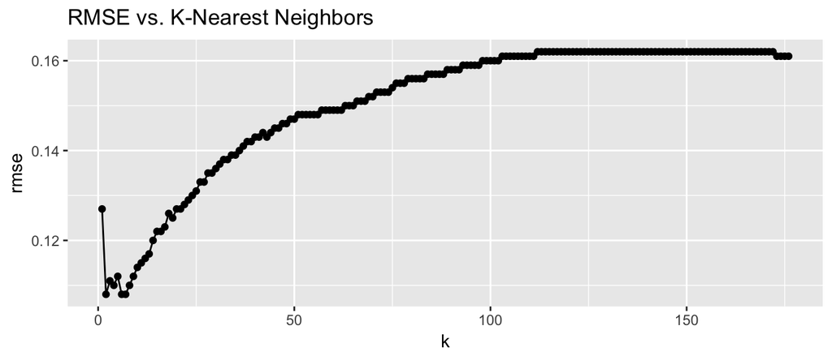

```r
  #opt
    logs <- knn.opt(xtrain, ytrain, xtest, ytest, nrow(xtest), 1)

  #Plot results
    ggplot(logs, aes(x = k, y = rmse)) +
            geom_line() + geom_point() + ggtitle("RMSE vs. K-Nearest Neighbors")
```

With this value, we can now put this finding to the test by plotting the interpolated data as a raster. Using the `ggplot` library, we will produce six graphs to illustrate the tolerances of the methods: the original and sampled images as well as a sampling of rasters for various values of $k$.

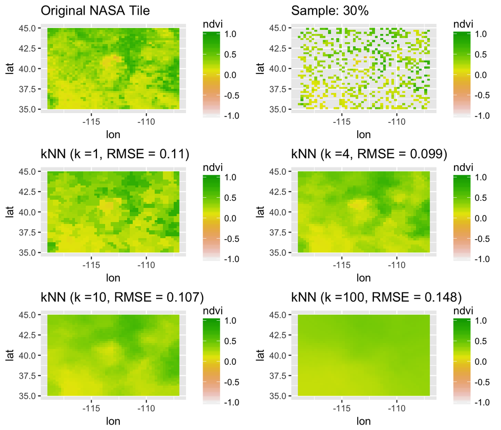

```r
#Original
  full <- ggplot(us_west, aes(x=lon, y=lat)) +
            geom_raster(aes(fill = ndvi)) +
            ggtitle("Original NASA Tile") +
            scale_fill_gradientn(limits = c(-1,1), colours = rev(terrain.colors(10)))

#30% sample
  sampled <- ggplot(sampled, aes(x=lon, y=lat)) +
            geom_raster(aes(fill = ndvi)) +
            ggtitle("Sample: 30%") +
            scale_fill_gradientn(limits = c(-1,1), colours = rev(terrain.colors(10)))

#Set new test set
  xtest <- as.matrix(us_west[, c(1,2)])

#Test k for four different values
  for(k in c(1, 4, 10, 100)){
    yhat <- knn.mean(xtrain,ytrain,xtest, k)
    pred <- data.frame(xtest, ndvi = yhat)
    rmse <- round(sqrt(mean((yhat  - us_west$ndvi)^2, na.rm=T)), 3)

    g <- ggplot(pred, aes(x=lon, y=lat)) +
      geom_raster(aes(fill = ndvi)) +
      ggtitle(paste0("kNN (k =",k,", RMSE = ", rmse,")")) +
      scale_fill_gradientn(limits = c(-1,1), colours = rev(terrain.colors(10)))

    assign(paste0("k",k), g)
  }

  #Graphs plotted
    library(gridExtra)
    grid.arrange(full, sampled, k1, k4, k10, k100, ncol=2)
```

#### Exercises 6.2

1. Write a function `dist()` that calculates the distance between all records of a two variable data frame `df` and a given reference coordinate. The reference coordinate will be an index $i$ of a row in the data frame (e.g. calculate the distance between row $i$ and all other points).
2. Expand that distance function to accept one or more variables. Use the example data to test your function.

```r
  set.seed(150)
  data <- data.frame(x1 = rnorm(1000, 10, 5),
                     x2 = rnorm(1000, 20, 35),
                     x3 = rnorm(1000, 14, 1),
                     x4 = rnorm(1000, 100, 200))
```

3. For the following values, write a function to retrieve the value of $y$ where $k = 1$ for each record $i$.
4. Modify the function to handle $k = 2$.

## Answers

#### Exercises 6.1 - OLS

The goal of this exercise is to illustrate that some times, training models on discrete units of analysis may yield better results than on a global basis. A global model is one where all data is pooled together, assuming similar relationships. A local model partitions the data into smaller cells to hone in on the unique signal in those cells.

Using the `tollroad_ols.csv` dataset, we can compare MAPE values to see the performance of a global versus local model. The practical application of this is to understand that running a regression on each `FIPS` code may yield better predictive results.

```r
setwd("<set-working-directory>")
df <- read.csv("tollroad_ols.csv")
```

```r
df$date <- as.Date(df$date, "%Y-%m-%d")
df$fips <- factor(df$fips)
df$flag <- 0
df$flag[df$year >= 2015] <- 1
```

```r
#Global model (df is all the data)
  fit <- lm(log(transactions) ~ log(emp) + log(bldgs) + log(wti_eia) + fips, data = df[df$flag==0,])
  df$yhat <- predict(fit, newdata = df)

#error in global
  train_g <- mape(df[df$flag == 0 & df$fips==24015, "yhat"], log(df[df$flag == 0 & df$fips==24015, "transactions"]))
  test_g <- mape(df[df$flag == 1 & df$fips==24015, "yhat"], log(df[df$flag == 1 & df$fips==24015, "transactions"]))

#Local model
  test <- df[df$fips==24015, ]
  fit24015 <- lm(log(transactions) ~ log(emp) + log(bldgs) + log(wti_eia), data = test[test$flag==0,])
  summary(fit24015)
```

```
##
## Call:
## lm(formula = log(transactions) ~ log(emp) + log(bldgs) + log(wti_eia),
##     data = test[test$flag == 0, ])
##
## Residuals:
##      Min       1Q   Median       3Q      Max
## -0.16606 -0.05454  0.00384  0.06421  0.14749
##
## Coefficients:
##               Estimate Std. Error t value Pr(>|t|)
## (Intercept)  -30.67718    7.98962  -3.840 0.000709 ***
## log(emp)       4.30697    0.77335   5.569 7.53e-06 ***
## log(bldgs)     0.17230    0.03822   4.509 0.000123 ***
## log(wti_eia)   0.01702    0.13663   0.125 0.901846
## ---
## Signif. codes:  0 '***' 0.001 '**' 0.01 '*' 0.05 '.' 0.1 ' ' 1
##
## Residual standard error: 0.08448 on 26 degrees of freedom
## Multiple R-squared:  0.6122, Adjusted R-squared:  0.5674
## F-statistic: 13.68 on 3 and 26 DF,  p-value: 1.502e-05
```

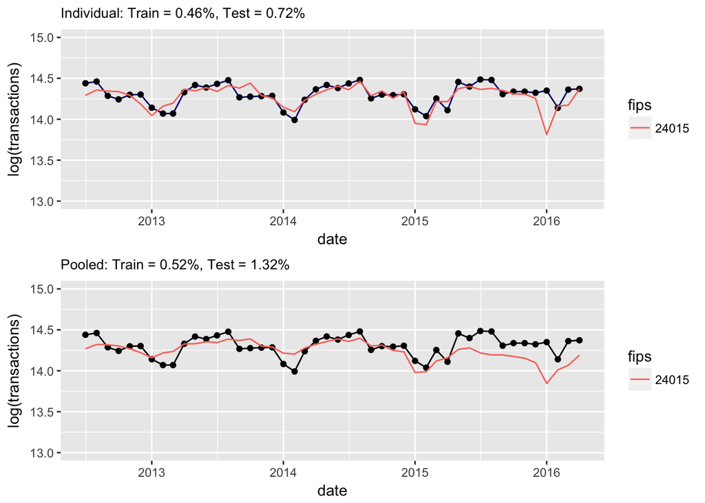

```r
  test$yhat <- predict(fit24015, newdata = test)

#error for local
  train_l <- mape(test[test$flag == 0, "yhat"], log(test[test$flag == 0, "transactions"]))
  test_l <- mape(test[test$flag == 1, "yhat"], log(test[test$flag == 1, "transactions"]))

  #Plot graphs (black line = actual)
  a <- ggplot(data = test,
         aes(x = date, y = log(transactions))) +
    geom_line(colour= "navy") +  geom_point()  +
    ggtitle(paste0("Individual: Train = ", round(100*train_l,2), "%, Test = ", round(100*test_l,2),"%")) +
    geom_line(aes(x = date, y = yhat, colour = fips)) +
    theme(plot.title = element_text(size = 10)) +
    ylim(c(13,15))

  b<-ggplot(data = df[df$fips == 24015,],
         aes(x = date, y = log(transactions))) +
    geom_line() +  geom_point()  +
    ggtitle(paste0("Pooled: Train = ", round(100*train_g,2), "%, Test = ", round(100*test_g,2),"%")) +
    geom_line(aes(x = date, y = yhat, colour = fips)) +
    theme(plot.title = element_text(size = 10))  + ylim(c(13,15))

  grid.arrange(a,b,ncol=1)
```

#### Exercises 6.2 - KNN

1. Write a function `dist()` that calculates the distance between all records of a two variable data frame `df` and a given reference coordinate. The reference coordinate will be an index `i` of a row in the data frame (e.g. calculate the distance between row `i` and all other points).

```r
  dist <- function(df, i){
    temp <- df[i,]
    dist <- sqrt(df[,1]^2 + df[,1]^2)
    return(dist)
  }
```

2. Expand that distance function to accept one or more variables.

```r
#Modify the function
  dist <- function(df, i){
    temp <- df[i,]
    col <- ncol(df)
    dist <- 0
    for(k in 1:col){
      dist <- dist + (df[,k] - temp[,k])^2
    }
    return(sqrt(dist))
  }

#Test it
  set.seed(150)
  data <- data.frame(x1 = rnorm(1000, 10, 5),
                     x2 = rnorm(1000, 20, 35),
                     x3 = rnorm(1000, 14, 1),
                     x4 = rnorm(1000, 100, 200))
  out <- dist(data, 1)
  head(out)
```

```
## [1]   0.0000 131.7022 122.2110 336.8763 263.7995 322.0519
```

3. Write a function to retrieve the value of $y$ where $k = 1$ for each record $i$.
4. Modify the function to handle $k = 2$.